# Neighbours and Enemies: Inter-Ethnic Exposure and Contentious Activity in Mandate Palestine

APSA 2026

Luqman Abu El Foul

London School of Economics and Political Science

## Motivation

Demographic change is generating political contention across the world, from anti-immigration riots in Europe to communal violence in South Asia.

**RQ**: How does local exposure to an ethnic outgroup shape the form and intensity of contentious activity?

## Theory

**Intergroup Contact**

- Contact with outgroup -> reduced prejudice -> less hostility
- Some evidence that it can reduce intergroup hostility (Alrababa’h et al. 2021; Sturgis et al. 2014; Weber 2019)

**Intergroup Conflict**

- Contact with outgroup -> threat to distinctiveness of ingroup, threat to balance of power, or competition over resources -> more hostility (Forbes 1997; Hardin 1995; Olzak 2022)
- Some evidence that it can increase intergroup hostility (Kaufmann and Harris 2015; McDoom 2013; Olzak 1992)

**Through what channel?**

- Conflict literature has identified three main mechanisms through which interethnic tensions may lead to conflict(Collier and Hoeffler 2004; Grossman 1991; Gurr 1970; Horowitz 1985):
  - **Opportunity-Cost** — higher the economic costs of participating in conflict -> stronger the incentive to abstain -> less conflict (Dube and Vargas 2013)
  - **Rapacity** — lootable resources -> material incentives to engage in conflict -> more conflict (McGuirk and Burke 2020)
  - **Resentment** — perceived injustice/threat -> collective anger -> more conflict (Cederman et al. 2011; Panza and Swee 2023)

## Theory

**Contentious Politics**

- Different repertoires of contention may possess different logics (Kadivar and Ketchley 2018; Tilly 2003)
- Differentiating by repertoire leads to different observable implications (Barrie et al. 2024)
- I apply this insight to all forms of interethnic contention (violent and non-violent)

**Hypotheses**

- *H1 (Baseline)*: Non-violent and violent forms of contentious activity will be higher in places where interethnic exposure is greater
- *H2 (Rapacity)*: Exposure should increase events characterised by appropriative repertoires (looting, theft, occupation)
- *H3 (Resentment)*: Exposure should disproportionately increase events characterised by destructive/punitive repertoires (arson, assault, destruction of property, bombing, stoning)
- *H4 (Opportunity Cost)*: The effect of interethnic exposure on contention will be greater where the economic costs of mobilising are lower

## Case Study: Mandate Palestine

**The Arab Revolt (1936-1939)**

- Phase 1: The Period of General Strike (15 April 1936 - 11 October 1936)
- Phase 2: Open Armed Revolt (22 June 1937 - 26 August 1939)

## Case Study: Mandate Palestine

**The Arab Revolt (1936-1939)**

- **Phase 1: The Period of General Strike (15 April 1936 - 11 October 1936)**
- Phase 2: Open Armed Revolt (22 June 1937 - 26 August 1939)

**Advantages**

- Direct focus on effects of Palestinian exposure to increased Jewish presence in Palestine
- Avoid time-varying confounders between phases (e.g. British anti-insurgency campaign)

## Data

**Event Dataset**

- Hand-coded event dataset covering the six-month period of the Revolt from an Arabic-language national-level daily newspaper (*Filastin*)
- Key variables recorded: date, location, size, actor, target, repertoires, whether an event was violent

**Other Data Sources**

- Palestinian Village Statistics (Palestine Remembered Project)
- Jewish Settlement Records (National Archives)
- Statistical Handbook of Jewish Palestine
- Jewish Settlement Composition (Panza and Zylberberg 2024)
- British Census Data

## Data

“*Just before **noon yesterday**, a bus **headed toward Bayit Vegan** was travelling **via al-Ajami street** under the protection of some members of the police. Yet, despite this police protection, **several [Palestinian] children threw stones and pieces of wood** at the bus causing the Jewish riders on board to duck for cover.*”

- Date: 13/05/1936
- Location: Jaffa
- Actor: Palestinians
- Target: Jews
- Repertoire: Stoning

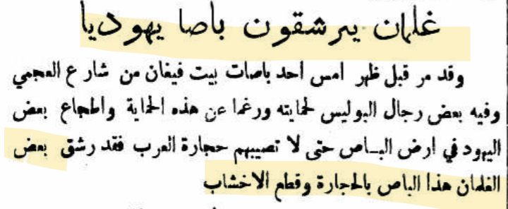

## Data

Descriptive Statistics of Contentious Events, April-October 1936

| Actor | Total | Violent | Non-violent |
| --- | --- | --- | --- |
| All Events | 7090 | 1961 | 5129 |
| British | 42 | 41 | 1 |
| Jews | 200 | 164 | 36 |
| Palestinians | 6607 | 1526 | 5081 |
| Unknown | 241 | 230 | 11 |

## Data

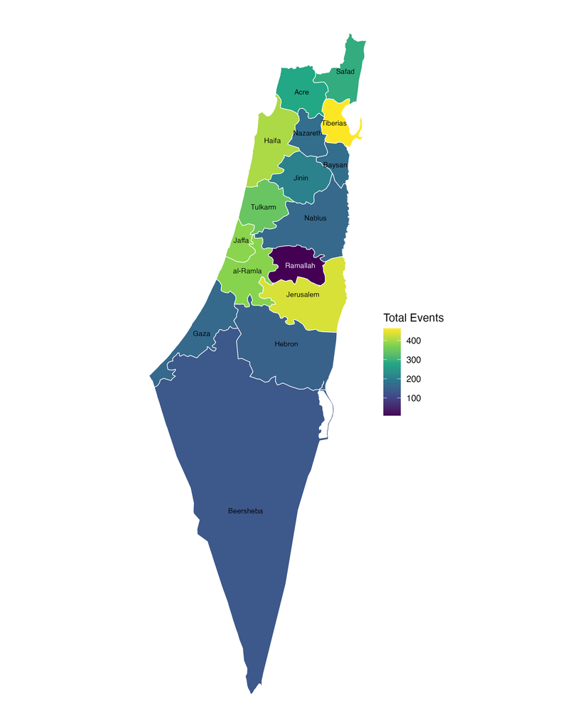

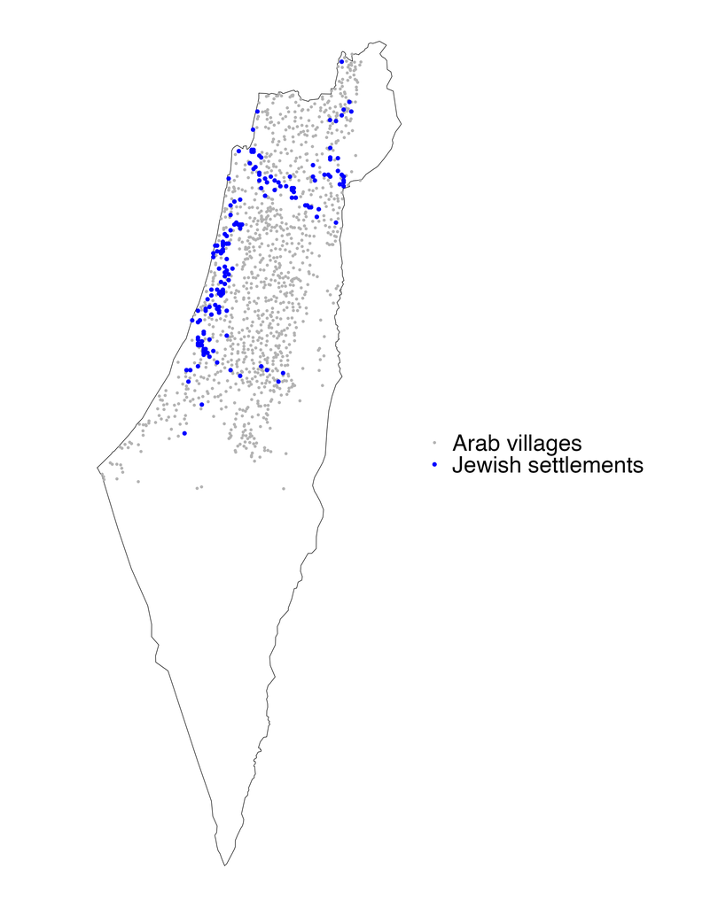

## Research Design

**Independent Variable**

- Distance weighted exposure of an Arab town/village to nearby Jewish populations
- But location of Jewish settlements is likely endogenous

## Research Design: Shift-Share Instrument

- Construct *predicted* Jewish population at each settlement using:
  - **Shares:** pre-1930 composition of each settlement by immigrant origin region
  - **Shifts:** 1930-1935 immigration flows by origin country
- Predicted population varies across settlements only because of differences in pre-existing origin composition

**Assumptions**:

- Jewish immigrants more likely to settle in settlements with a pre-existing population of their ethnic kin
- Origin-country immigration shocks are uncorrelated with village-level determinants of Palestinian contention
- Immigration flows driven by **push factors** in origin countries, not local Palestinian conditions (Buggle et al. 2023)
  - Rising antisemitism in Europe, particularly Nazi persecution post-1933
  - Polish economic restrictions on Jews

## Research Design: Shift-Share Instrument

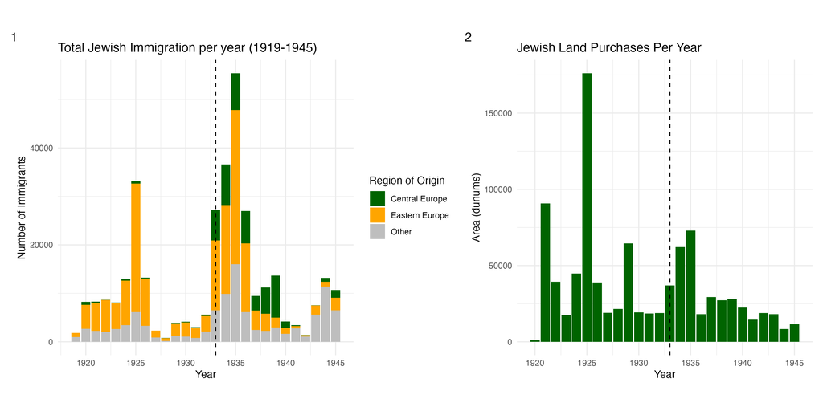

## Research Design: Shift-Share Instrument

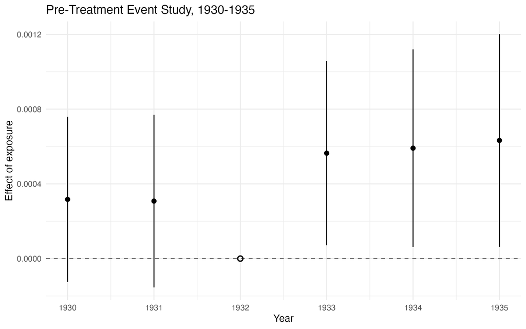

## From Settlement Exposure to Village Exposure

- For each Arab village, calculate distance-weighted exposure to predicted Jewish population across all nearby settlements
- Exponential decay: closer settlements receive more weight (decay rate = 0.2/km)
- “Half-life” of exposure is about 3.5km
- Robustness checks with alternative distance-decay functions

## Estimation Equation

- I estimate the following reduced form regression:

$$Y_i = \alpha + \beta Z_i + \delta_d + \epsilon_i$$

## Main Results

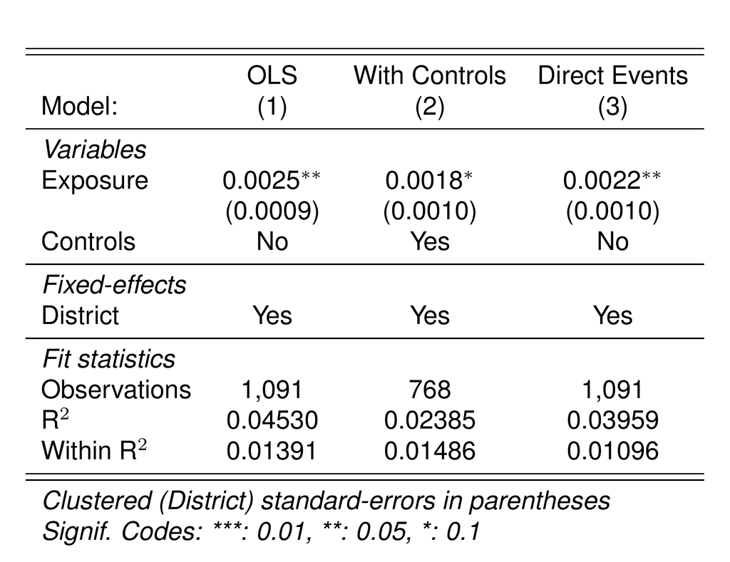

Interpretation: Moving from the 25th to the 75th percentile of predicted exposure leads to 1.77 additional contentious events per village, representing a 48% increase relative to the sample mean.

## Heterogeneous Effects: Violent and Non-violent Events

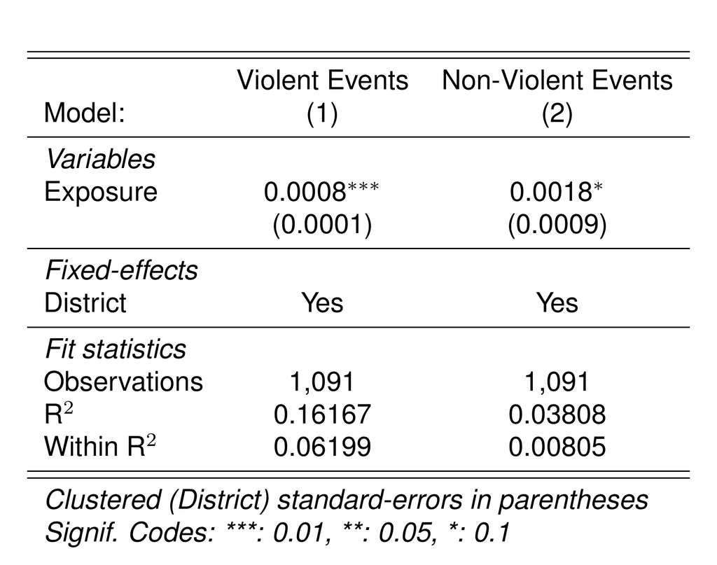

Interpretation: Moving from the 25th to the 75th percentile of predicted exposure leads to 0.53 additional violent and 1.24 additional non-violent events, equivalent to a 79% and 41% increase relative to sample mean.

## Mechanism: Rapacity

- If material gain motivates participation, expect appropriative repertoires (looting, theft, occupation)
- Only **8 events** in the dataset involve appropriative repertoires

**Result:** Insufficient evidence to support rapacity as a mechanism

## Mechanism: Resentment

- Exposure should disproportionately increase destructive/punitive events
- Subset: arson, assault, destruction of property, bombing, stoning (n=243)

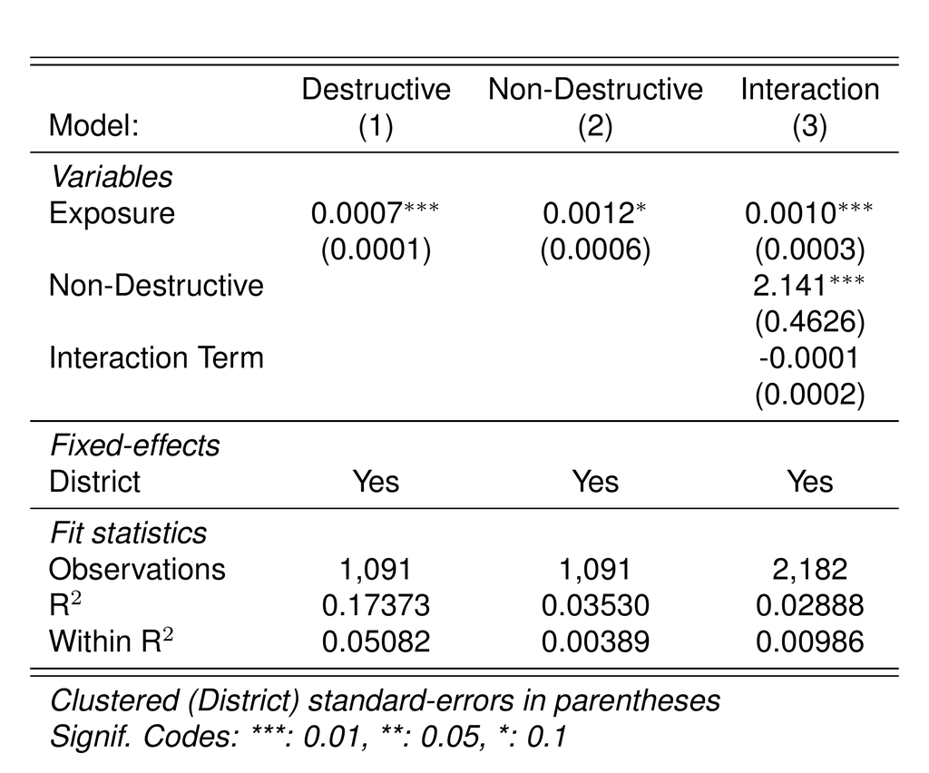

## Mechanism: Opportunity Cost

- The effect of exposure on contention should be greater where the economic costs of mobilising are lower
- Test: If exposure raises contention by lowering economic costs of mobilization, the effect should be stronger in villages dependent on subsistence cereal agriculture.

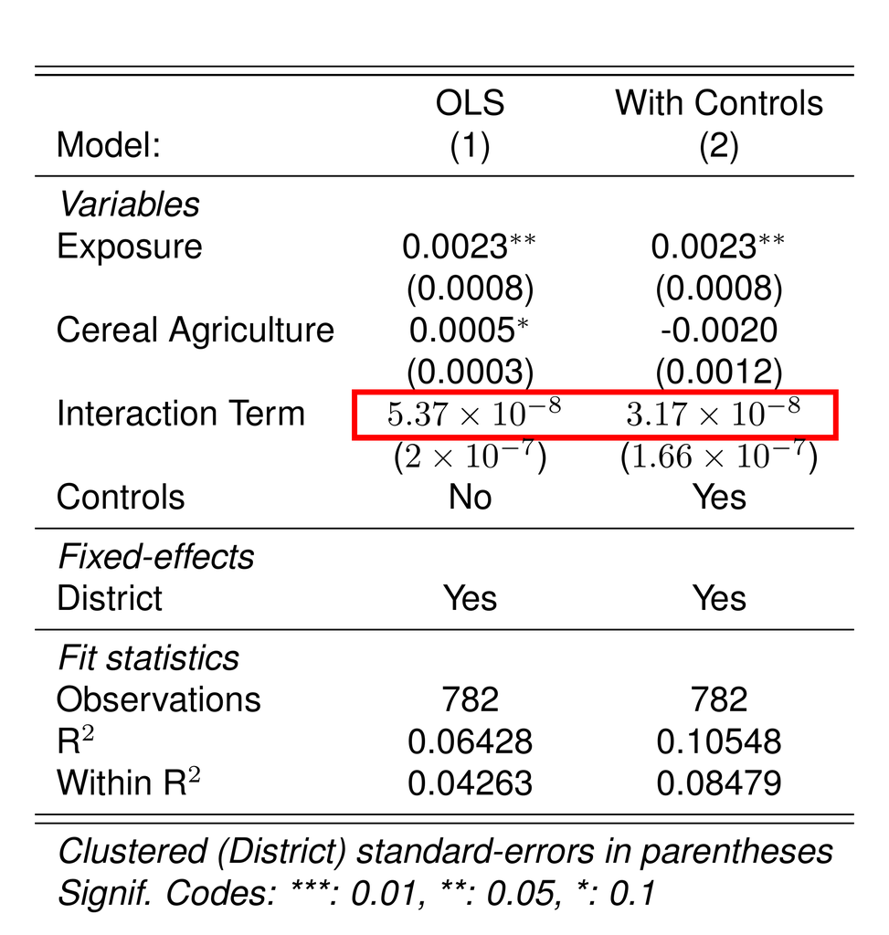

## Conclusion

- Palestinian exposure to Jewish settlements seems to increase the rate of contentious activity (both violent and non-violent)
- No evidence that this effect is operating through mechanisms of rapacity and opportunity cost
- Suggestive evidence that this effect is operating through mechanism of resentment

**Next Steps**:

- Examine how accurate my predicted Jewish population measure is
- More robustness checks

# Thank you!

l.abu-el-foul@lse.ac.uk

luqmanabuelfoul.com

# Appendix

## Alternative Distance-Decay Functions

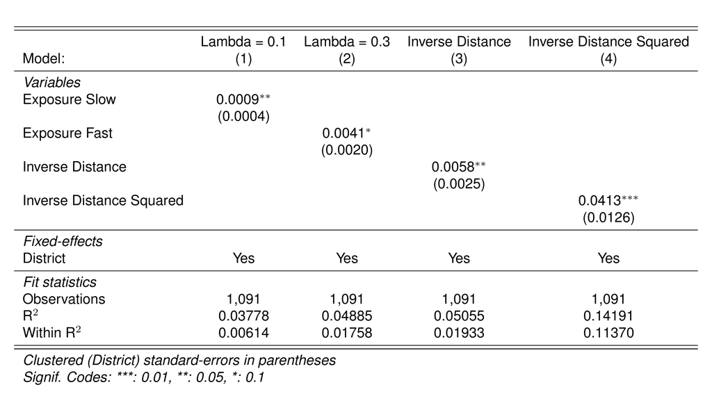

## Negative Binomial Count Model

|  | Direct Events (NB) |
| --- | --- |
| Predicted Exposure | 0.00074*** |
|  | (0.00016) |
| Num.Obs. | 1091 |
| Log.Lik. | −676.652 |

* p < 0.1, ** p < 0.05, *** p < 0.01  
Standard errors clustered at the district level.  
District fixed effects included.

## No-Strike Events

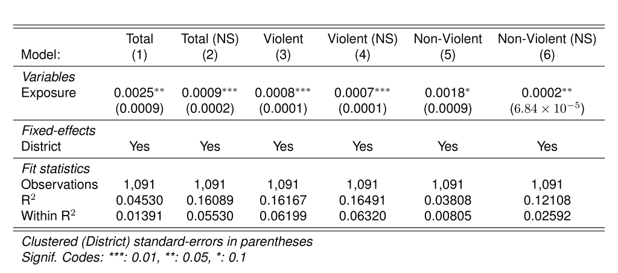

## Balance Tests

Balance Tests: Covariate Balance on Predicted Exposure

| Variable | Mean | SD | Coefficient | SE | P-value | N | Stars |
| --- | --- | --- | --- | --- | --- | --- | --- |
| Cultivable Land (dunams) | 7263.435 | 9899.836 | -1.86e-01 | 2.53e-01 | 0.462 | 794 |  |
| Cereal Land (dunams) | 5806.063 | 8751.286 | -1.56e-01 | 1.05e-01 | 0.139 | 782 |  |
| Citrus Land (dunams) | 842.958 | 1335.939 | 4.45e-02 | 9.38e-02 | 0.636 | 166 |  |
| Elevation (m) | 331.526 | 264.438 | -2.42e-02 | 1.28e-02 | 0.058 | 768 | * |
| Distance to District Centre (km) | 15.951 | 8.851 | -5.89e-04 | 6.37e-04 | 0.356 | 839 |  |
| Arab Population (1931) | 1419.246 | 4339.019 | 5.60e-01 | 6.36e-01 | 0.379 | 240 |  |

## Bibliography

Alrababa’h, Ala’, William Marble, Salma Mousa, and Alexandra A. Siegel. 2021. “Can Exposure to Celebrities Reduce Prejudice? The Effect of Mohamed Salah on Islamophobic Behaviors and Attitudes.” *American Political Science Review* 115 (4): 1111–28. https://doi.org/10.1017/S0003055421000423.

Barrie, Christopher, Killian Clarke, and Neil Ketchley. 2024. “Burnings, Beatings, and Bombings: Disaggregating Anti-Christian Violence in Egypt, 20132018.” *Perspectives on Politics* 22 (2): 481–500. https://doi.org/10.1017/S1537592722002730.

Buggle, Johannes, Thierry Mayer, Seyhun Orcan Sakalli, and Mathias Thoenig. 2023. “Refugee’s Dilemma: Evidence from Jewish Migration out of Nazi Germany*.” *Quarterly Journal of Economics* 138 (2): 1273–345. https://doi.org/10.1093/qje/qjad001.

Cederman, Lars-Erik, Nils B. Weidmann, and Kristian Skrede Gleditsch. 2011. “Horizontal Inequalities and Ethnonationalist Civil War: A Global Comparison.” *The American Political Science Review* 105 (3): 478–95. https://www.jstor.org.gate3.library.lse.ac.uk/stable/41480853.

Collier, Paul, and Anke Hoeffler. 2004. “Greed and Grievance in Civil War.” *Oxford Economic Papers* 56 (4): 563–95. https://www.jstor.org/stable/3488799.

Dube, Oeindrila, and Juan F. Vargas. 2013. “Commodity Price Shocks and Civil Conflict: Evidence from Colombia.” *The Review of Economic Studies* 80 (4 (285)): 1384–421. https://www.jstor.org.gate3.library.lse.ac.uk/stable/43551562.

Forbes, H. D. 1997. *Ethnic Conflict: Commerce, Culture, and the Contact Hypothesis*. Yale University Press. https://www.jstor.org/stable/j.ctt32bhp7.

Grossman, Herschell I. 1991. “A General Equilibrium Model of Insurrections.” *The American Economic Review* 81 (4): 912–21. https://www.jstor.org/stable/2006650.

Gurr, Ted Robert. 1970. *Why men rebel*. Princeton University Press.

Hardin, Russell. 1995. *One for All: The Logic of Group Conflict*. Princeton University Press. https://doi.org/10.2307/j.ctt7sd6q.

Horowitz, Donald L. 1985. *Ethnic groups in conflict*. University of California Press.

Kadivar, Mohammad Ali, and Neil Ketchley. 2018. “Sticks, Stones, and Molotov Cocktails: Unarmed Collective Violence and Democratization.” *Socius* 4 (June): 1–16. https://doi.org/10.1177/2378023118773614.

Kaufmann, Eric, and Gareth Harris. 2015. ““White Flight” or Positive Contact? Local Diversity and Attitudes to Immigration in Britain.” *Comparative Political Studies* 48 (12): 1563–90. https://doi.org/10.1177/0010414015581684.

McDoom, Omar Shahabudin. 2013. “Who Killed in Rwanda’s Genocide? Micro-Space, Social Influence and Individual Participation in Intergroup Violence.” *Journal of Peace Research* 50 (4): 453–67. https://www.jstor.org/stable/23441211.

McGuirk, Eoin, and Marshall Burke. 2020. “The Economic Origins of Conflict in Africa.” *Journal of Political Economy* 128 (10): 3940–97. https://doi.org/10.1086/709993.

Olzak, Susan. 1992. *The dynamics of ethnic competition and conflict*. Stanford University Press.

Olzak, Susan. 2022. *Competition and Ethnic/Racial Collective Action*. John Wiley & Sons, Ltd. https://doi.org/10.1002/9780470674871.wbespm043.pub2.

Panza, Laura, and Eik Leong Swee. 2023. “Fanning the Flames: Rainfall Shocks, Inter-Ethnic Income Inequality, and Conflict Intensification in Mandate Palestine.” *Journal of Economic Behavior & Organization* 206 (February): 71–94. https://doi.org/10.1016/j.jebo.2022.11.032.

Panza, Laura, and Yanos Zylberberg. 2024. “Nation-Building and Mass Migration: Evidence from Mandatory Palestine.” *SSRN Electronic Journal*, ahead of print. https://doi.org/10.2139/ssrn.4721467.

Sturgis, Patrick, Brunton-Smith ,Ian, Kuha ,Jouni, and Jonathan and Jackson. 2014. “Ethnic Diversity, Segregation and the Social Cohesion of Neighbourhoods in London.” *Ethnic and Racial Studies* 37 (8): 1286–309. https://doi.org/10.1080/01419870.2013.831932.

Tilly, Charles. 2003. *The Politics of Collective Violence*. Cambridge Studies in Contentious Politics. University Press.

Weber, Hannes. 2019. “Attitudes Towards Minorities in Times of High Immigration: A Panel Study Among Young Adults in Germany.” *European Sociological Review* 35 (2): 239–57. https://www.jstor.org/stable/48563165.